# Poisson Regression

Tarek El-Hajjaoui

2023-04-10

Beyond Multiple Linear Regression Applied Generalized Linear Models and Multilevel Models in R Paul Roback and Julie Legler

## Conceptual Exercises

Exercises 1-4 involve predicting a response using one or more explanatory variables, where these examples have response variables that are counts per some unit of time or space. List the response (both what is being counted and over what unit of time or space) and relevant explanatory variables.

### Q 4.11.1.2

Does the number of employers conducting on-campus interviews during a year differ for public and private colleges?

- Response = number of employers conducting on-campus interviews per year
  - What is being counted: number of employees
  - Over what unit of time or space: year (time)
- Explanatory Variable
  - $X_1$ is an indicator variable for indicating public or private school

### Q 4.11.1.4

Has the number of deformed fish in randomly selected Minnesota lakes been affected by changes in trace minerals in the water over the last decade?

- Response = number of deformed fish in randomly selected Minnesota lakes
  - What is being counted: number of deformed fish
  - Over what unit of time or space: selected Minnesota lakes (space)
- Explanatory Variable
  - $X_1$ is a continuous variable the amount of changes in trace minerals in the water over the last decade

### Q 4.11.1.12 Methadone program recidivism.

Program facilitators keep track of the number of times their program’s patients relapse within five years of initial treatment. Data on 100 patients yielded a mean number of 2.8 relapses per patient within the five years of initial treatment.

#### Q 4.11.1.12. a

Define the response.

- Response (Y) = the number of relapses per patient within the five years of initial treatment.

#### Q 4.11.1.12. b

What are the possible values for the response?

- (0, $\infty$)

#### Q 4.11.1.12. c

What does $\lambda$ represent?

- $\lambda$ represents the average number of relapses per patient within the five years of initial treatment.

## Guided Exercises

### 4.11.2.1 College burglaries.

We wish to build a regression model to describe the number of burglaries on a college campus in a year. Our population of interest will be U.S. liberal arts colleges.

#### 4.11.2.1.a

Describe why the response variable (Y= # burglaries on campus in a year) could be modeled by a Poisson distribution.

- Poisson regression can be used to model λ, the average number of burglaries on campus in a year. The average number of burglaries on campus in a year is a discrete variable and Poisson models a discrete probability distribution. The burglaries on campus most likely are independent which supports the use of Poisson modeling. If the mean and variance of the number of burglaries on campus are relatively the same then that would also support the use of Poisson modeling.

#### 4.11.2.1.b

Describe explanatory variables which might explain differences in $\lambda_i$ = mean number of burglaries per year on campus i.

- Public University vs Private University
- Location (Country, State, City, Zipcode, etc.)
- Ratio of campus security per number of student

#### 4.11.2.1.c

Consider a campus with an average of 5 burglaries per year. Use dpois() to sketch a plot of the distribution of Y for this campus.

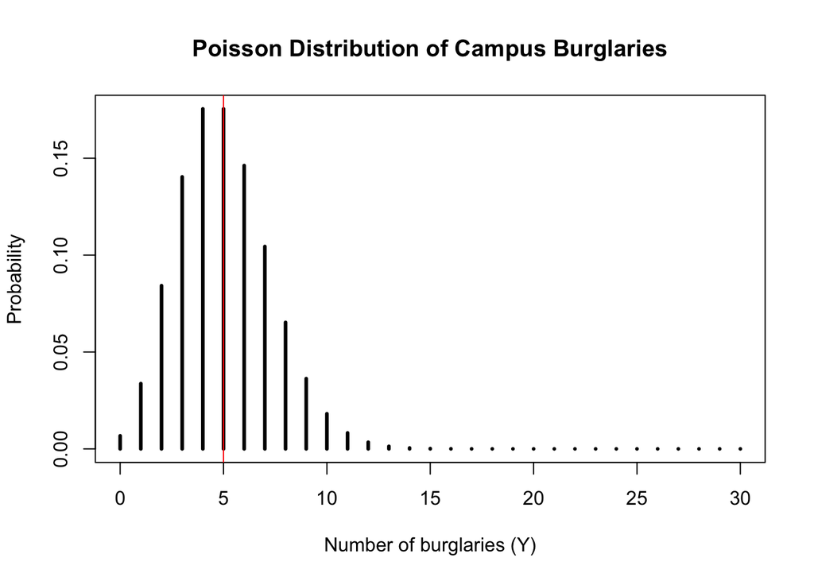

```r
# set the lambda parameter to 5 (average of 5 burglaries per year)
lambda <- 5

# create a sequence of 30 possible values for Y
y_seq <- 0:30

# calculate the probability of each value of Y
y_prob <- dpois(y_seq, lambda)

# plot the Poisson distribution of Y
plot(y_seq, y_prob, type = "h", lwd = 3,
     xlab = "Number of burglaries (Y)", ylab = "Probability",
     main = "Poisson Distribution of Campus Burglaries")

# Add a vertical line at the mean of the distribution
abline(v = lambda, col = "red")
```

Use rpois() to verify that both the mean and variance of Y are given by $\lambda$ = 5.

```r
# generate 10,000 random samples from the Poisson distribution
set.seed(0)
y_samples <- rpois(n = 10000, lambda = 5)

# mean of the samples
mean(y_samples)
```

```
## [1] 5.0075
```

```r
# variance of the samples
var(y_samples)
```

```
## [1] 5.101954
```

#### 4.11.2.1.d

Consider a campus with an average of 20 burglaries per year and repeat (c).

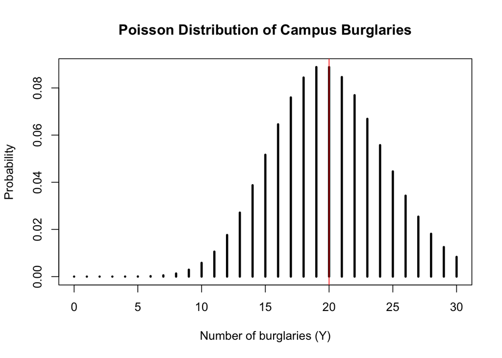

```r
# set the lambda parameter to 20 (average of 20 burglaries per year)
lambda <- 20

# create a sequence of 30 possible values for Y
y_seq <- 0:30

# calculate the probability of each value of Y
y_prob <- dpois(y_seq, lambda)

# plot the Poisson distribution of Y
plot(y_seq, y_prob, type = "h", lwd = 3,
     xlab = "Number of burglaries (Y)", ylab = "Probability",
     main = "Poisson Distribution of Campus Burglaries")

# Add a vertical line at the mean of the distribution
abline(v = lambda, col = "red")
```

Use rpois() to verify that both the mean and variance of Y are given by $\lambda$ = 20.

```r
# generate 10,000 random samples from the Poisson distribution
set.seed(0)
y_samples <- rpois(n = 10000, lambda = 20)

# mean of the samples
mean(y_samples)
```

```
## [1] 20.0024
```

```r
# variance of the samples
var(y_samples)
```

```
## [1] 20.13741
```

### 4.11.2.5 Campus crime.

The data set campuscrime09.csv contains the number of burglaries reported at a collection of 47 U.S. public universities with over 10,000 students in the year 2009. In addition, covariates are included which may explain differences in crime rates, including total number of students, percentage of men, average SAT and ACT test scores, and tuition.

```r
# Loading the dataset
file_path = '/Users/Tarek/Documents/UCI_MDS_Coding/Stats211P/R_Statistical_Modeling/PoissonRegression/campuscrime09.csv'
df = read.csv(file_path, header = TRUE)
```

#### 4.11.2.5 a

Perform an exploratory data analysis. Support your analysis with plots and summary statistics.

```r
# Transforming categorical columns to factor data type.
categorical_cols <- c('institution', 'state')
df[categorical_cols] <- lapply(df[categorical_cols], as.factor)
```

```r
# summary of dataset
str(df)
```

```
## 'data.frame':    47 obs. of  12 variables:
##  $ Idnum      : int  16 51 60 71 73 92 112 113 123 131 ...
##  $ institution: Factor w/ 47 levels "Central Michigan University",..: 1 2 3 4 5 6 7 8 9 10 ...
##  $ mentotal   : int  11517 10830 9471 14467 9752 10024 21986 11744 18777 28528 ...
##  $ total      : int  27247 27654 22893 32067 24408 25127 47071 25188 33819 55014 ...
##  $ pct.male   : num  42.3 39.2 41.4 45.1 40 ...
##  $ sat.math   : num  540 520 515 565 580 510 600 520 610 635 ...
##  $ sat.read   : int  525 495 510 550 550 515 550 515 570 595 ...
##  $ sat.tot    : num  532 508 512 558 565 ...
##  $ state      : Factor w/ 20 levels "IN","MI","MN",..: 2 5 2 18 2 10 2 15 5 10 ...
##  $ tuition    : int  23590 16386 9278 23376 9630 10006 11842 18916 6216 10119 ...
##  $ act.comp   : num  22 21 20.5 25 24 21.5 25 22.5 24.5 27.5 ...
##  $ burg09     : int  27 10 42 4 1 15 123 41 29 178 ...
```

```r
# features of interest
# total number of students, percentage of men, average SAT and ACT test scores, and tuition
features <- c('total','pct.male', 'sat.tot', 'act.comp', 'tuition')
multiple.func <- function(x) {
      c(summary = summary(x), var = var(x))
}
sapply(df[features], multiple.func)
```

```
##                       total pct.male   sat.tot  act.comp     tuition
## summary.Min.       21424.00 38.44287  477.5000 20.500000     5740.00
## summary.1st Qu.    24914.00 44.44604  525.0000 21.750000     8413.00
## summary.Median     28765.00 47.46188  555.0000 24.000000    10674.00
## summary.Mean       31329.28 47.61662  561.7819 24.170213    13223.89
## summary.3rd Qu.    34411.00 49.55547  592.5000 26.000000    16397.00
## summary.Max.       55014.00 58.56718  665.0000 29.500000    30866.00
## var             76985784.07 21.51647 2102.4962  6.253006 40312377.40
```

1. Analyze whether number of burglaries could be reasonably modeled with a Poisson distribution.

To see if a Poisson distribution is appropriate, graphs of the total burglaries against each of the empirical mean of each feature variables are created below:

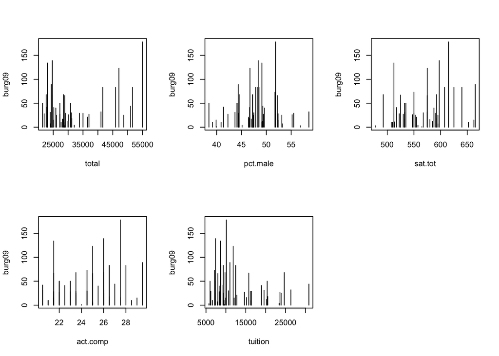

```r
# Create a matrix for plots
par(mfrow = c(2, 3))
plot(df[['total']], df$burg09, xlab='total', ylab="burg09", type = "h")
plot(df[['pct.male']], df$burg09, xlab='pct.male', ylab="burg09", type = "h")
plot(df[['sat.tot']], df$burg09, xlab='sat.tot', ylab="burg09", type = "h")
plot(df[['act.comp']], df$burg09, xlab='act.comp', ylab="burg09", type = "h")
plot(df[['tuition']], df$burg09, xlab='tuition', ylab="burg09", type = "h")

# plotting burg09 against the empirical mean of each feature variable
# for (feat in features) {
#   plot(df[[feat]], df$burg09, xlab=feat, ylab="burg09")
# }
```

The graphs above suggest that the number of burglaries follow a Poisson distribution (discussed more below).

2. Analyze which covariates you expect to be the best predictors of burglaries.
- Number of burglars appears to follow a Poisson distribution based on variables: tuition and act.comp (ACT score). For example, the plot with tuition appears to be a Poisson distribution with a right-skew which is commonly found in Poisson samples. Number of burglars against pct.male (percent male), sat.tot (SAT total score), and total (total number of students) does not appear to follow a Poisson distribution. For example, the pct.male plot appears to follow the distribution instead appears to be a normal distribution.

#### 4.11.2.5 b

Consider a model with 4 predictors: act.comp + tuition + pct.male + total. Try fitting a linear regression with burg09 as the response.

```r
lm_model <- lm(burg09 ~ act.comp + tuition + pct.male + total, data=df)
summary(lm_model)
```

```
##
## Call:
## lm(formula = burg09 ~ act.comp + tuition + pct.male + total,
##     data = df)
##
## Residuals:
##    Min     1Q Median     3Q    Max
## -58.35 -24.71  -4.64  16.03 101.26
##
## Coefficients:
##               Estimate Std. Error t value Pr(>|t|)
## (Intercept)  3.7889197 75.4066999   0.050   0.9602
## act.comp     2.3845399  2.5249907   0.944   0.3504
## tuition     -0.0017851  0.0009177  -1.945   0.0585 .
## pct.male    -0.8219242  1.2885673  -0.638   0.5270
## total        0.0014540  0.0007756   1.875   0.0678 .
## ---
## Signif. codes:  0 '***' 0.001 '**' 0.01 '*' 0.05 '.' 0.1 ' ' 1
##
## Residual standard error: 37.12 on 42 degrees of freedom
## Multiple R-squared:  0.1801, Adjusted R-squared:  0.102
## F-statistic: 2.307 on 4 and 42 DF,  p-value: 0.07387
```

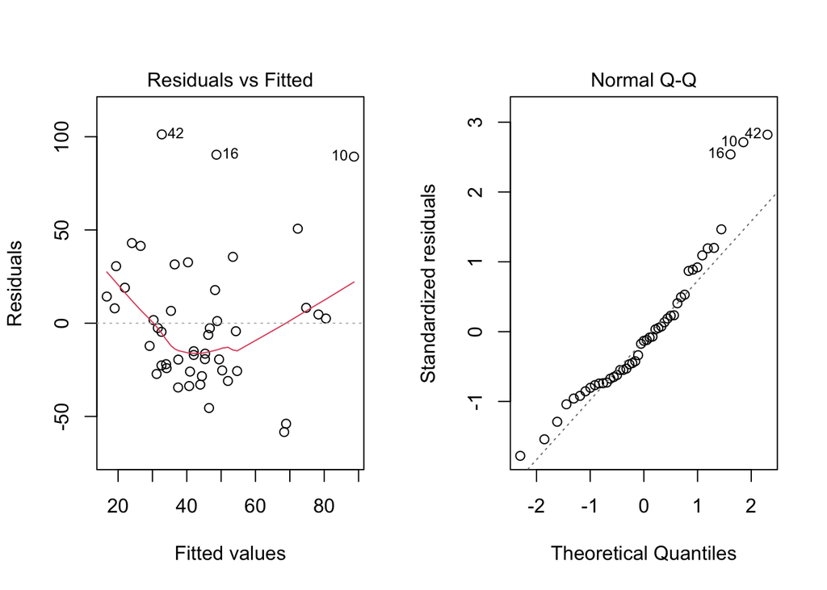

```r
# Create a matrix of four plots to check the assumptions of linear regression
par(mfrow = c(1, 2))

# Residuals vs. Fitted Values plot
plot(lm_model, 1)

# Normal Q-Q plot
plot(lm_model, 2)
```

Are there any concerns with this linear regression model?

#### 4.11.2.5 c

Run a Poisson regression model with the 4 predictors from (b). Interpret the coefficients for tuition and pct.male.

```r
poisson_model <- glm(burg09 ~ act.comp + tuition + pct.male + total, family=poisson, data=df)
summary(poisson_model)
```

```
##
## Call:
## glm(formula = burg09 ~ act.comp + tuition + pct.male + total,
##     family = poisson, data = df)
##
## Deviance Residuals:
##     Min       1Q   Median       3Q      Max
## -8.9601  -4.3267  -0.7979   2.0759  12.9673
##
## Coefficients:
##               Estimate Std. Error z value Pr(>|z|)
## (Intercept)  2.741e+00  3.238e-01   8.465  < 2e-16 ***
## act.comp     5.352e-02  1.008e-02   5.308 1.11e-07 ***
## tuition     -3.896e-05  3.937e-06  -9.894  < 2e-16 ***
## pct.male    -1.313e-02  5.355e-03  -2.452   0.0142 *
## total        2.666e-05  2.745e-06   9.709  < 2e-16 ***
## ---
## Signif. codes:  0 '***' 0.001 '**' 0.01 '*' 0.05 '.' 0.1 ' ' 1
##
## (Dispersion parameter for poisson family taken to be 1)
##
##     Null deviance: 1400.0  on 46  degrees of freedom
## Residual deviance: 1133.6  on 42  degrees of freedom
## AIC: 1389
##
## Number of Fisher Scoring iterations: 5
```

```r
# Obtaining coefficient estimates
coef_estimates <- coef(poisson_model)

# Exponentiating coefficients to be able to interpret coefficients
# Because exponentiating the coefficient allows us
# to obtain the multiplicative factor by which the mean count changes
exp_coef <- exp(coef_estimates)
exp_coef
```

```
## (Intercept)    act.comp     tuition    pct.male       total
##  15.4979106   1.0549809   0.9999610   0.9869548   1.0000267
```

For a **1 unit increase in the predictor variable**:

- act.comp: the expected the response variable ($\lambda$ = estimated mean number of burglaries) would increase by a factor of approximately 1.0549809 holding all other variables constant.
- tuition: the expected the response variable ($\lambda$ = estimated mean number of burglaries) would decrease by a factor of approximately 0.9999610 holding all other variables constant.
- pct.male: the expected the response variable ($\lambda$ = estimated mean number of burglaries) would decrease by a factor of approximately 0.9869548 holding all other variables constant.
- total: the expected the response variable ($\lambda$ = estimated mean number of burglaries) would increase by a factor of approximately 1.0000267 holding all other variables constant.

#### 4.11.2.5 d

Replace tuition with tuition in thousands in your model from (c) – i.e., tuition.thous=tuition/1000. How does your new model compare to your model in (c)? Interpret the coefficient for tuition.thous.

```r
# add a new variable to the dataframe that is a tuition divided by 1000
df$tuition_thous <- df$tuition / 1000
sapply(df[c('tuition', 'tuition_thous')], multiple.func)
```

```
##                     tuition tuition_thous
## summary.Min.        5740.00       5.74000
## summary.1st Qu.     8413.00       8.41300
## summary.Median     10674.00      10.67400
## summary.Mean       13223.89      13.22389
## summary.3rd Qu.    16397.00      16.39700
## summary.Max.       30866.00      30.86600
## var             40312377.40      40.31238
```

```r
poisson_model_2 <- glm(burg09 ~ act.comp + tuition_thous + pct.male + total, family=poisson, data=df)
summary(poisson_model_2)
```

```
##
## Call:
## glm(formula = burg09 ~ act.comp + tuition_thous + pct.male +
##     total, family = poisson, data = df)
##
## Deviance Residuals:
##     Min       1Q   Median       3Q      Max
## -8.9601  -4.3267  -0.7979   2.0759  12.9673
##
## Coefficients:
##                 Estimate Std. Error z value Pr(>|z|)
## (Intercept)    2.741e+00  3.238e-01   8.465  < 2e-16 ***
## act.comp       5.352e-02  1.008e-02   5.308 1.11e-07 ***
## tuition_thous -3.896e-02  3.937e-03  -9.894  < 2e-16 ***
## pct.male      -1.313e-02  5.355e-03  -2.452   0.0142 *
## total          2.666e-05  2.745e-06   9.709  < 2e-16 ***
## ---
## Signif. codes:  0 '***' 0.001 '**' 0.01 '*' 0.05 '.' 0.1 ' ' 1
##
## (Dispersion parameter for poisson family taken to be 1)
##
##     Null deviance: 1400.0  on 46  degrees of freedom
## Residual deviance: 1133.6  on 42  degrees of freedom
## AIC: 1389
##
## Number of Fisher Scoring iterations: 5
```

```r
# Obtaining coefficient estimates
coef_estimates_2 <- coef(poisson_model_2)['tuition_thous']

# Exponentiating coefficients to be able to interpret coefficients
exp_coef_2 <- exp(coef_estimates_2)
exp_coef_2
```

```
## tuition_thous
##     0.9617923
```

For a **1000 unit increase in tuition**:

- tuition_thou: the expected the response variable ($\lambda$ = estimated mean number of burglaries) would decrease by a factor of approximately 0.9617923 holding all other variables constant.